# Day 5

# Python Control Mouse & Keyboard

## Olly&Lan

# Book

[figure not shown]

- Automate the Boring Stuff with Python
  - [Translated Book](https://www.tenlong.com.tw/products/9789864762729)
  - [Online eBook](https://automatetheboringstuff.com/)
  - [Online Course -Udemy](https://softnshare.wordpress.com/2016/11/23/automateboringstuffwithpython/)
- Environment require Python 3.4+

# Contents:

### 1. [Basic python](https://github.com/iamshihshan/PyOllyTutorial/blob/master/01_Basic%20Python.ipynb)

- Statement Assignment
- print()
- str()
- for i in range(n)
- try: & exception:

### 2. Third-party modules

- [pyautogui](https://pyautogui.readthedocs.io/en/latest/)
- [time](https://docs.python.org/3.5/library/time.html)

# Install pyautogui Module

### If you have native python you can install module as below :

```
cmd
pip install pyautogui
```

### If you use conda you can install module as below :

```
cmd
conda install -c conda-forge pyautogui
```

[figure not shown]

# Check Modules Exist

### You don't need to install time, because time is in [standard library](https://docs.python.org/3//library/index.html).

### Without Error Massage!!

```
import pyautogui
import time
```

# Let's Start!

# pyautogui Module

- PyAutoGUI can simulate
  - moving the mouse
  - clicking the mouse
  - dragging with the mouse
  - pressing keys
  - pressing and holding keys
  - pressing keyboard hotkey combinations.

# If pyautogui Too Fast/Out of Control

- Shutting down everything by logging out

# How to Prevent

- Wait **n** seconds for each PyAutoGUI function call
- Moving the mouse cursor to the **upper-left corner of the screen** will raise the *pyautogui.FailSafeException*

  ```
  import pyautogui
  pyautogui.PAUSE = 1 #default 0.1s
  pyautogui.FAILSAFE = True #default True
  ```

# Controlling Mouse Movement

# Find Cursor Location

- The upper-left corner of the screen (x, y) = (0, 0)
- The x coordinate increases going to right, and the y coordinate increases going down
- All coordinates are positive integers

[figure not shown]

# Screen Size and on the Screen

- Return tuple of integer: (width, height) for size of your main monitor

  ```
  pyautogui.size()
  ```

- Check if XY coordinates are on the screen

  ```
  pyautogui.onScreen(x, y)
  ```

```python
import pyautogui
print(pyautogui.size())
pyautogui.onScreen(0,1000)
```

```
(1440, 900)
```

```
False
```

### Store the width and height as variables for better readability in your programs

```python
width, height = pyautogui.size()
```

# Moving the Mouse

```
pyautogui.moveTo(x, y, duration=seconds)
#If 0, then the mouse cursor is moved instantaneously. 0.0 by default.
pyautogui.moveRel(xOffset, yOffset, duration=seconds)
```

- duration: The amount of time it takes to move the mouse cursor to the new xy coordinates.

```python
for i in range(5):
    pyautogui.moveTo(100, 100, duration=0.25)
    pyautogui.moveTo(200, 100, duration=0.25)
    pyautogui.moveTo(200, 200, duration=0.25)
    pyautogui.moveTo(100, 200, duration=0.25)
```

```python
for i in range(5):
    pyautogui.moveRel(100, 0, duration=0.25)
    pyautogui.moveRel(0, 100, duration=0.25)
    pyautogui.moveRel(-100, 0, duration=0.25)
    pyautogui.moveRel(0, -100, duration=0.25)
```

# Getting the Mouse Position

```
pyautogui.position()
```

### Return x and y of your cursor on screen now

```python
pyautogui.position()
```

```
(326, 223)
```

# Project : “Where Is the Mouse Right Now?”

### Aim :

- Display the current x and y coordinate of the mouse cursor.
- Update these coordinates as the mouse moves around the screen.

### Demo

[figure not shown]

### Step 1: Import the Module

### Step 2: Set Up the Quit Code and Infinite Loop

### Step 3: Get and Print the Mouse Coordinates

# Step 1: Import the Module

```python
import pyautogui
print('Press Ctrl-C to quit.')
```

```
Press Ctrl-C to quit.
```

# Step 2: Set Up the Quit Code and Infinite Loop

```python
try:
    while True:
    # TODO: Get and print the mouse coordinates.
except KeyboardInterrupt:
    print('\nDone.')
```

# Step 3: Get and Print the Mouse Coordinates

### To erase text, print the \b backspace escape character

```python
x, y = pyautogui.position()
positionStr = 'X: ' + str(x).rjust(4) + ', Y: ' + str(y).rjust(4)
print(positionStr, end='')
print('\b' * len(positionStr), end='', flush=True)
```

# Program File

### Please download WhereIsMouse.py and execute WhereIsMouse.py in terminal.

### Or execute program below on Jupyter notebook

```
from IPython.display import display, clear_output
import pyautogui
import time

try:
    while True:
        # TODO: Get and print the mouse coordinates.
        x, y = pyautogui.position()
        positionStr = 'X: ' + str(x).rjust(4) + ', Y: ' + str(y).rjust(4)
        display(positionStr)
        time.sleep(0.2)
        clear_output(wait=True)
except:
    print('\nDone.')
```

# Controlling Mouse Interaction

# Clicking the Mouse

```
pyautogui.click(x, y, button='left')
pyautogui.mouseDown(x, y, button='left')
pyautogui.mouseUp(x, y, button='left')
# or multiple clicks
pyautogui.click(clicks=3, interval=0.25, button='right')
pyautogui.doubleClick(x, y)
```

- Button could be left, right or middle to specify which you want

```python
import pyautogui
pyautogui.click(400, 300)
```

### Equal

```python
import pyautogui
pyautogui.mouseDown(400, 300)
pyautogui.mouseUp(400, 300)
```

# Dragging the Mouse

```
pyautogui.dragTo(x, y, duration=2)
pyautogui.dragRel(xOffset, yOffset, duration=0.25, button='right')
```

```python
### demo
import pyautogui
#drag google chrome icon in dock
pyautogui.moveTo(910, 880)
pyautogui.dragTo(985, 880, duration=2)
pyautogui.dragRel(-75, 0, duration=2)
```

# Project : “Drawing with pyautogui”

### Aim :

- Create Graphic Automatically
- Draw something by pyautogui

[figure not shown]

### Demo

### During program sleep :

### Try to move the mouse cursor over the drawing window and select pencil/brush

### [Online sketch](https://sketch.io/sketchpad/)

```python
import pyautogui, time
time.sleep(5)
pyautogui.click()
distance = 200
while distance > 0:
    pyautogui.dragRel(distance, 0, duration=0.2)   # move right
    distance = distance - 5
    pyautogui.dragRel(0, distance, duration=0.2)   # move down
    pyautogui.dragRel(-distance, 0, duration=0.2)  # move left
    distance = distance - 5
    pyautogui.dragRel(0, -distance, duration=0.2)  # move up
```

# Scrolling the Mouse

### The size of a scroll unit varies for each operating system and application

```
pyautogui.scroll(unit)
```

```python
import pyautogui
import time
pyautogui.moveRel(0,200, duration=1)
for i in range(3):
    time.sleep(2)
    pyautogui.scroll(-3)
```

# Working with the Screen

# Getting a Screenshot

```
pyautogui.screenshot()
pyautogui.screenshot(region=(left, top, width, height))
#(left, top) is the upper left corner
```

```
/Users/nancy/pyladies
```

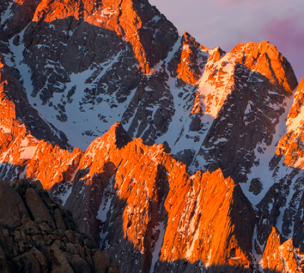

```python
import pyautogui, time
import os
time.sleep(2)
im = pyautogui.screenshot(imageFilename='screenshot.png',region=(360, 225, 500, 450))

#current directory
print(os.getcwd())
im
```

# Color of the Pixel at Coordinate in Image

```
Image.getpixel((x, y))
```

### Return an RGBA tuple

1. Amount of **red** in the pixel
2. Amount of **green** in the pixel
3. Amount of **blue** in the pixel
4. Amount of **alpha** in the pixel

#### Note that the range for red, green and blue is 0-255.

```python
im.getpixel((0, 0))
```

```
(41, 36, 48, 255)
```

# Recognize Color

```
pyautogui.pixelMatchesColor(x, y, (R, G, B))
```

- If the pixel at the given x- and y-coordinate on the screen matches the given color, pixelMatchesColor() function will return True

```python
time.sleep(1)
pyautogui.pixelMatchesColor(360, 225, (41, 36, 48))
```

```
True
```

# Project: "Extending the WhereIsMouse Program"

### Aim

- Add recognize function in WhereIsMouse program

### Demo

[figure not shown]

### [Test your color IQ](http://xritephoto.com/cool-tools)

```
#! python
import pyautogui
print('Press Ctrl-C to quit.')
try:
    while True:
        # TODO: Get and print the mouse coordinates.
        x, y = pyautogui.position()
        positionStr = 'X: ' + str(x).rjust(4) + ' Y: ' + str(y).rjust(4)
        # Add Code Here!!!!!
        # Add Code Here!!!!!
        # Add Code Here!!!!!
        # Add Code Here!!!!!
        print(positionStr, end='')
        print('\b' * len(positionStr), end='', flush=True)
except KeyboardInterrupt:
    print('\nDone.')
```

### Download full code here WhereIsMouse_WithRBG.py

### Add below code into WhereIsMouse.py

```
pixelColor = pyautogui.screenshot().getpixel((x, y))
positionStr += ' RGB: (' + str(pixelColor[0]).rjust(3)
positionStr += ', ' + str(pixelColor[1]).rjust(3)
positionStr += ', ' + str(pixelColor[2]).rjust(3) + ')'
```

# Image Recognition

[figure not shown]

```python
import pyautogui
import time
time.sleep(2)
pyautogui.locateOnScreen('Img/screenshot.png')
#Returns (left, top, width, height) coordinate of first found instance of the image on the screen.
```

[output not shown]

```python
time.sleep(1)
print(pyautogui.locateAllOnScreen('Img/screenshot.png'))
list(pyautogui.locateAllOnScreen('Img/screenshot.png'))
```

```
<generator object _locateAll_python at 0x11442bbf8>
```

[output not shown]

# Controlling the Keyboard

# Sending a String from the Keyboard

```
pyautogui.typewrite(string, seconds)
```

### Try to open text editor or Google Doc during program sleep, pyautogui will keyin Hello world!

```python
import time, pyautogui
time.sleep(10)
pyautogui.click(100, 100)
pyautogui.typewrite('Hello world!', 0.25)
```

# Key Names

```
pyautogui.typewrite(['KeyName',...], seconds)
```

| Keyboard Key String | Meaning |
| --- | --- |
| 'a', 'b', 'c', 'A', 'B', 'C', '1', '2', '3', '!', '@', '#', and so on | The keys for single characters |
| 'left' | The left arrow keys |

- PyAutoGUI [KEYBOARD_KEYS](https://pyautogui.readthedocs.io/en/latest/keyboard.html?highlight=typewrite#keyboard-keys)

```python
import time, pyautogui
time.sleep(10)
pyautogui.click(100, 100)
pyautogui.typewrite(['O', 'l', 'l', 'y', '!', '!', 'left', 'left', ' ', ',', 'H', 'I'], 0.25)
```

| Keyboard Key String | Meaning |
| --- | --- |
| 'a', 'b', 'c', 'A', 'B', 'C', '1', '2', '3', '!', '@', '#', and so on | The keys for single characters |
| 'enter' (or 'return' or '\n') | The ENTER key |
| 'esc' | The ESC key |
| 'shiftleft', 'shiftright' | The left and right SHIFT keys |
| 'altleft', 'altright' | The left and right ALT keys |
| 'ctrlleft', 'ctrlright' | The left and right CTRL keys |
| 'tab' (or '\t') | The TAB key |
| 'backspace', 'delete' | The BACKSPACE and DELETE keys |
| 'pageup', 'pagedown' | The PAGE UP and PAGE DOWN keys |
| 'home', 'end' | The HOME and END keys |
| 'up', 'down', 'left', 'right' | The up, down, left, and right arrow keys |

| Keyboard Key String | Meaning |
| --- | --- |
| 'f1', 'f2', 'f3', and so on | The F1 to F12 keys |
| 'volumemute', 'volumedown', 'volumeup' | The mute, volume down, and volume up keys (some keyboards do not have these keys, but your operating system will still be able to understand these simulated keypresses) |
| 'pause' | The PAUSE key |
| 'capslock', 'numlock', 'scrolllock' | The CAPS LOCK, NUM LOCK, and SCROLL LOCK keys |
| 'insert' | The INS or INSERT key |
| 'printscreen' | The PRTSC or PRINT SCREEN key |
| 'winleft', 'winright' | The left and right WIN keys (on Windows) |
| 'command' | The Command () key (on OS X) 'option' The OPTION key (on OS X) |

# Pressing and Releasing the Keyboard

```
pyautogui.keyDown(key)
pyautogui.keyUpd(key)
```

### How to hold the SHIFT key to get "$"?

```python
import time, pyautogui
time.sleep(10)
pyautogui.click(500, 500)
pyautogui.keyDown('shift')
pyautogui.press('4')
pyautogui.keyUp('shift')
```

# Hotkey Combinations

```
pyautogui.hotkey('ctrl', 'c',...)
```

### Select ALL = Ctrl/Command + a

### Copy = Ctrl/Command + c

```python
import pyautogui
pyautogui.keyDown('ctrl')
pyautogui.keyDown('a')
pyautogui.keyDown('c')
pyautogui.keyUp('c')
pyautogui.keyUp('a')
pyautogui.keyUp('ctrl')
```

### Equal

```python
import pyautogui
pyautogui.hotkey('ctrl', 'a', 'c')
```

# Exercise

### Open browser, type in url, launch [Konami Code](https://en.wikipedia.org/wiki/Konami_Code)

1. Use subprocess module to open browser
2. Input url and remember to press enter
3. Focus on the center of screen
4. Press Konami Code

### Demo

### Answer

```python
import time, pyautogui, subprocess
subprocess.Popen(['open', '/Applications/Safari.app/'])
time.sleep(1)
pyautogui.typewrite('https://playoverwatch.com/zh-tw/', interval=0.25)
pyautogui.press('enter')
time.sleep(1)
x, y = pyautogui.size()
time.sleep(1)
pyautogui.click(x/2, y/2)
pyautogui.press(['up', 'up', 'down', 'down', 'left', 'right', 'left', 'right', 'b', 'a'], interval=0.5)
```

# def Day5End() :